# Most common programming languages used in Chain

## Introduction

With the emerging technology in Chain such as Artificial Intelligence and Data Science, many programming languages that were poorly spoken and used are now experiencing a rise in popularity.

You may have already heard “Python is the programming language of the moment” or “Functional Paradigm is much better than Object Oriented”.

As the world’s largest and most trusted community of software developers, stackoverflow runs this survey and share these results to improve developers’ lives. The website wants to empower developers by providing them with rich information about themselves, their industry, and their peers. I used data from Stackoverflow ’s Annual Developer Surveys of year 2018 and 2019. The surveys data covers lot of features of developers , including 'Country',’age’,’IT/Programming experience’,’industry’,’size of company’,’occupation’,’languages’,’salary’.

Every year, Stack Overflow conducts a massive survey of people on the site, covering all sorts of information like programming languages, jobs, code style and various other information.

Motivation behind this project includes answer to following questions:

```
- Most common Programming Languages used in chain?
- Most wanted Programming Languages used in Chain?
- Which occupations were most popular in each year?
```

```python
# to handle datasets
import numpy as np
import pandas as pd
from collections import Counter

# to visualise al the columns in the dataframe
pd.pandas.set_option('display.max_columns', None)

# to make plots
import matplotlib.pyplot as plt
import seaborn as sns

# to ignore warnings
import warnings
```

```python
# Reading Stackoverflow survey data
df_2018 = pd.read_csv('survey_results_2018.csv')
df_2019 = pd.read_csv('survey_results_2019.csv')
```

```python
df_2018.head()
```

|  | Respondent | Hobby | OpenSource | Country | Student | Employment | FormalEducation | UndergradMajor | CompanySize | DevType | YearsCoding | YearsCodingProf | JobSatisfaction | CareerSatisfaction | HopeFiveYears | JobSearchStatus | LastNewJob | AssessJob1 | AssessJob2 | AssessJob3 | AssessJob4 | AssessJob5 | AssessJob6 | AssessJob7 | AssessJob8 | AssessJob9 | AssessJob10 | AssessBenefits1 | AssessBenefits2 | … |
| --- | --- | --- | --- | --- | --- | --- | --- | --- | --- | --- | --- | --- | --- | --- | --- | --- | --- | --- | --- | --- | --- | --- | --- | --- | --- | --- | --- | --- | --- | --- |
| 0 | 1 | Yes | No | Kenya | No | Employed part-time | Bachelor’s degree (BA, BS, B.Eng., etc.) | Mathematics or statistics | 20 to 99 employees | Full-stack developer | 3-5 years | 3-5 years | Extremely satisfied | Extremely satisfied | Working as a founder or co-founder of my own c... | I’m not actively looking, but I am open to new... | Less than a year ago | 10.0 | 7.0 | 8.0 | 1.0 | 2.0 | 5.0 | 3.0 | 4.0 | 9.0 | 6.0 | NaN | NaN | … |
| 1 | 3 | Yes | Yes | United Kingdom | No | Employed full-time | Bachelor’s degree (BA, BS, B.Eng., etc.) | A natural science (ex. biology, chemistry, phy... | 10,000 or more employees | Database administrator;DevOps specialist;Full-... | 30 or more years | 18-20 years | Moderately dissatisfied | Neither satisfied nor dissatisfied | Working in a different or more specialized tec... | I am actively looking for a job | More than 4 years ago | 1.0 | 7.0 | 10.0 | 8.0 | 2.0 | 5.0 | 4.0 | 3.0 | 6.0 | 9.0 | 1.0 | 5.0 | … |
| 2 | 4 | Yes | Yes | United States | No | Employed full-time | Associate degree | Computer science, computer engineering, or sof... | 20 to 99 employees | Engineering manager;Full-stack developer | 24-26 years | 6-8 years | Moderately satisfied | Moderately satisfied | Working as a founder or co-founder of my own c... | I’m not actively looking, but I am open to new... | Less than a year ago | NaN | NaN | NaN | NaN | NaN | NaN | NaN | NaN | NaN | NaN | NaN | NaN | … |
| 3 | 5 | No | No | United States | No | Employed full-time | Bachelor’s degree (BA, BS, B.Eng., etc.) | Computer science, computer engineering, or sof... | 100 to 499 employees | Full-stack developer | 18-20 years | 12-14 years | Neither satisfied nor dissatisfied | Slightly dissatisfied | Working as a founder or co-founder of my own c... | I’m not actively looking, but I am open to new... | Less than a year ago | NaN | NaN | NaN | NaN | NaN | NaN | NaN | NaN | NaN | NaN | NaN | NaN | … |
| 4 | 7 | Yes | No | South Africa | Yes, part-time | Employed full-time | Some college/university study without earning ... | Computer science, computer engineering, or sof... | 10,000 or more employees | Data or business analyst;Desktop or enterprise... | 6-8 years | 0-2 years | Slightly satisfied | Moderately satisfied | Working in a different or more specialized tec... | I’m not actively looking, but I am open to new... | Between 1 and 2 years ago | 8.0 | 5.0 | 7.0 | 1.0 | 2.0 | 6.0 | 4.0 | 3.0 | 10.0 | 9.0 | 1.0 | 10.0 | … |

```python
df_2019.head()
```

|  | Respondent | MainBranch | Hobbyist | OpenSourcer | OpenSource | Employment | Country | Student | EdLevel | UndergradMajor | EduOther | OrgSize | DevType | YearsCode | Age1stCode | YearsCodePro | CareerSat | JobSat | MgrIdiot | MgrMoney | MgrWant | JobSeek | LastHireDate | LastInt | FizzBuzz | JobFactors | ResumeUpdate | CurrencySymbol | CurrencyDesc | … |
| --- | --- | --- | --- | --- | --- | --- | --- | --- | --- | --- | --- | --- | --- | --- | --- | --- | --- | --- | --- | --- | --- | --- | --- | --- | --- | --- | --- | --- | --- | --- |
| 0 | 1 | I am a student who is learning to code | Yes | Never | The quality of OSS and closed source software ... | Not employed, and not looking for work | United Kingdom | No | Primary/elementary school | NaN | Taught yourself a new language, framework, or ... | NaN | NaN | 4 | 10 | NaN | NaN | NaN | NaN | NaN | NaN | NaN | NaN | NaN | NaN | NaN | NaN | NaN | NaN | … |
| 1 | 2 | I am a student who is learning to code | No | Less than once per year | The quality of OSS and closed source software ... | Not employed, but looking for work | Bosnia and Herzegovina | Yes, full-time | Secondary school (e.g. American high school, G... | NaN | Taken an online course in programming or softw... | NaN | Developer, desktop or enterprise applications;... | NaN | 17 | NaN | NaN | NaN | NaN | NaN | NaN | I am actively looking for a job | I've never had a job | NaN | NaN | Financial performance or funding status of the... | Something else changed (education, award, medi... | NaN | NaN | … |
| 2 | 3 | I am not primarily a developer, but I write co... | Yes | Never | The quality of OSS and closed source software ... | Employed full-time | Thailand | No | Bachelor’s degree (BA, BS, B.Eng., etc.) | Web development or web design | Taught yourself a new language, framework, or ... | 100 to 499 employees | Designer;Developer, back-end;Developer, front-... | 3 | 22 | 1 | Slightly satisfied | Slightly satisfied | Not at all confident | Not sure | Not sure | I’m not actively looking, but I am open to new... | 1-2 years ago | Interview with people in peer roles | No | Languages, frameworks, and other technologies ... | I was preparing for a job search | THB | Thai baht | … |
| 3 | 4 | I am a developer by profession | No | Never | The quality of OSS and closed source software ... | Employed full-time | United States | No | Bachelor’s degree (BA, BS, B.Eng., etc.) | Computer science, computer engineering, or sof... | Taken an online course in programming or softw... | 100 to 499 employees | Developer, full-stack | 3 | 16 | Less than 1 year | Very satisfied | Slightly satisfied | Very confident | No | Not sure | I am not interested in new job opportunities | Less than a year ago | Write code by hand (e.g., on a whiteboard);Int... | No | Languages, frameworks, and other technologies ... | I was preparing for a job search | USD | United States dollar | … |
| 4 | 5 | I am a developer by profession | Yes | Once a month or more often | OSS is, on average, of HIGHER quality than pro... | Employed full-time | Ukraine | No | Bachelor’s degree (BA, BS, B.Eng., etc.) | Computer science, computer engineering, or sof... | Taken an online course in programming or softw... | 10,000 or more employees | Academic researcher;Developer, desktop or ente... | 16 | 14 | 9 | Very dissatisfied | Slightly dissatisfied | Somewhat confident | Yes | No | I am not interested in new job opportunities | Less than a year ago | Write any code;Write code by hand (e.g., on a ... | No | Industry that I'd be working in;Languages, fra... | I was preparing for a job search | UAH | Ukrainian hryvnia | … |

```python
df_2018.columns
```

```
Index(['Respondent', 'Hobby', 'OpenSource', 'Country', 'Student', 'Employment',
       'FormalEducation', 'UndergradMajor', 'CompanySize', 'DevType',
       ...
       'Exercise', 'Gender', 'SexualOrientation', 'EducationParents',
       'RaceEthnicity', 'Age', 'Dependents', 'MilitaryUS', 'SurveyTooLong',
       'SurveyEasy'],
      dtype='object', length=129)
```

```python
df_2018.columns
```

```
Index(['Respondent', 'Hobby', 'OpenSource', 'Country', 'Student', 'Employment',
       'FormalEducation', 'UndergradMajor', 'CompanySize', 'DevType',
       ...
       'Exercise', 'Gender', 'SexualOrientation', 'EducationParents',
       'RaceEthnicity', 'Age', 'Dependents', 'MilitaryUS', 'SurveyTooLong',
       'SurveyEasy'],
      dtype='object', length=129)
```

```python
def filter_country(df, column_filter, country, columns):
    ''' Filter a dataframe by country.,
        returns filtred dataframe.
    '''

    df_copy = df

    for column in columns:
        df_copy = df_copy[df_copy[column_filter] == country].dropna(subset=[column])

    return df_copy

# Filter the dataframe by India and selecting some columns.
China_2018 = filter_country(df_2018, 'Country', 'China', ['LanguageWorkedWith', 'LanguageDesireNextYear'])
China_2019 = filter_country(df_2019, 'Country', 'China', ['LanguageWorkedWith', 'LanguageDesireNextYear'])
```

```python
def filter_occupation(df, column_filter, country, columns):
    ''' Filter a dataframe by country.,
        returns filtred dataframe.
    '''

    df_copy = df

    for column in columns:
        df_copy = df_copy[df_copy[column_filter] == country].dropna(subset=[column])

    return df_copy

# Filter the dataframe by India and selecting some columns.
China_2018_occ = filter_country(df_2018, 'Country', 'China', ['DevType'])
China_2019_occ = filter_country(df_2019, 'Country', 'China', ['DevType'])
```

```python
def split_column(df, column):
    ''' Split column by ;,
        returns a splited series.
    '''

    df_copy = df
    column_series = df_copy[column].apply(lambda x: x.split(';'))

    return column_series

# Splitting the Data Frame by column into a Series.
worked_lang_2018 = split_column(China_2018, 'LanguageWorkedWith')
wanted_lang_2018 = split_column(China_2018, 'LanguageDesireNextYear')

worked_lang_2019 = split_column(China_2019, 'LanguageWorkedWith')
wanted_lang_2019 = split_column(China_2019, 'LanguageDesireNextYear')

occ_2018 = split_column(China_2018_occ, 'DevType')
occ_2019 = split_column(China_2019_occ, 'DevType')
```

```python
def disarray(array_list):
    ''' Flat a nested list,
        returns a flat list.
    '''

    objects = []

    for row in array_list:
        for obj in row:
            objects.append(obj.strip())

    return objects

# Flatting nested list objects.
list_worked_languages_2018 = disarray(worked_lang_2018)
list_wanted_languages_2018 = disarray(wanted_lang_2018)

list_worked_languages_2019 = disarray(worked_lang_2019)
list_wanted_languages_2019 = disarray(wanted_lang_2019)

list_occ_2018 = disarray(occ_2018)
list_occ_2019 = disarray(occ_2019)
```

```python
def group_list(data_list, year):
    ''' Group by count to a list,
        returns a result dict.
    '''

    grouped_list = dict(Counter(data_list))
    grouped_dict = [{'Programming Language':key, 'Count': value, 'Year': year} for key, value in grouped_list.items()]

    return grouped_dict

# Groping a list and creating a dict.
dict_worked_languages_2018 = group_list(list_worked_languages_2018, '2018')
dict_wanted_languages_2018 = group_list(list_wanted_languages_2018, '2018')

dict_worked_languages_2019 = group_list(list_worked_languages_2019, '2019')
dict_wanted_languages_2019 = group_list(list_wanted_languages_2019, '2019')

dict_occupation_2018 = group_list(list_occ_2018, '2018')
dict_occupation_2019 = group_list(list_occ_2019, '2019')
```

```python
def create_dataframe(data_dicts):
    ''' Create two dataframes and append them,
        returns a appended dataframe.
    '''

    df1 = pd.DataFrame(data_dicts[0])
    df2 = pd.DataFrame(data_dicts[1])

    df = df1.append(df2)

    return df

# Creating a Data Frame appending the data.
worked_languages = create_dataframe([dict_worked_languages_2018, dict_worked_languages_2019])
wanted_languages = create_dataframe([dict_wanted_languages_2018, dict_wanted_languages_2019])

occupation = create_dataframe([dict_occupation_2018, dict_occupation_2019])
```

```python
def percentage(df, column):
    ''' Scale data,
        returns data scaled.
    '''

    df_copy = df
    series = []

    for val in df_copy[column].unique():
        series.append(df_copy[df_copy[column] == val]['Count'] /
                      df_copy[df_copy[column] == val]['Count'].sum())

    joined_series = pd.Series()
    for i_series in series:
        joined_series = joined_series.append(i_series)

    return joined_series

# Calculating the percentage
worked_languages['Percentage'] = percentage(worked_languages, 'Year')
wanted_languages['Percentage'] = percentage(wanted_languages, 'Year')

occupation['Percentage'] = percentage(occupation, 'Year')
```

```python
# Get the top 10 languages
top_10_worked_lang = worked_languages.sort_values(by=['Percentage'], ascending=False).head(10)['Programming Language'].unique()
top_10_wanted_lang = wanted_languages.sort_values(by=['Percentage'], ascending=False).head(10)['Programming Language'].unique()

top_10_occupation = occupation.sort_values(by=['Percentage'], ascending=False).head(10)['Programming Language'].unique()


worked_lang_chart = worked_languages[worked_languages['Programming Language'].isin(top_10_worked_lang)]
wanted_lang_chart = wanted_languages[wanted_languages['Programming Language'].isin(top_10_worked_lang)]

occupation_chart = occupation[occupation['Programming Language'].isin(top_10_occupation)]
```

# Most common Programming Languages used in chain ?

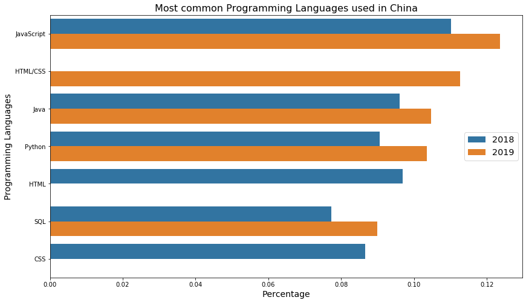

```python
plt.figure(figsize=(14,8))
sns.barplot(x = 'Percentage',
            y = 'Programming Language',
            hue = 'Year',
            data = worked_lang_chart.sort_values(by='Percentage', ascending=False))

plt.xlabel("Percentage", fontsize = 14)
plt.ylabel("Programming Languages", fontsize = 14)
plt.legend(fontsize='x-large', title_fontsize='40')
plt.title('Most common Programming Languages used in China', size = 16)
plt.show()
```

We can see that commonly used programming languages like: Java Script, HTML/CSS, Java and Python are still in the top positions. Stack Overflow survey data 2018 and 2019

# Most wanted Programming Languages used in Chain?

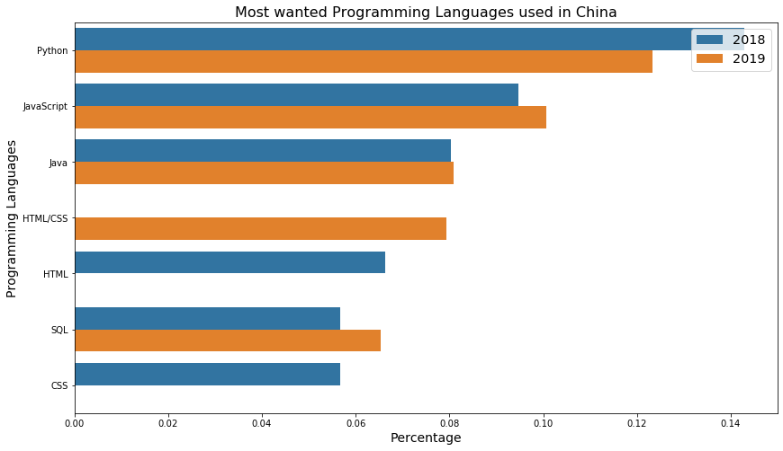

```python
plt.figure(figsize=(14,8))
sns.barplot(x = 'Percentage',
            y = 'Programming Language',
            hue = 'Year',
            data = wanted_lang_chart.sort_values(by='Percentage', ascending=False))

plt.title('Most wanted Programming Languages used in China', size = 16)
plt.xlabel("Percentage", fontsize = 14)
plt.ylabel("Programming Languages", fontsize = 14)
plt.legend(fontsize='x-large', title_fontsize='40')
plt.show()
```

We can see that Most Wanted used programming languages like: Python , JavaScript and Java are still in the top positions. Stack Overflow survey data 2018 and 2019

# How does programming languages used at work relates with programming languages people want to learn?

```python
rows = []
for items in list(zip(worked_lang_2018, wanted_lang_2018)):
    for i in items[0]:
        rows.append({
            'Worked_PL': i,
            'Wanted_PL': Counter(items[0])
        })

programming_language_transition = pd.DataFrame(rows).groupby('Worked_PL').agg({'Wanted_PL': 'sum'}).reset_index()
```

```python
for row in programming_language_transition['Worked_PL']:
    programming_language_transition[row] = 0

for index, row in programming_language_transition.iterrows():
    total = sum([value for key, value in dict(row['Wanted_PL']).items()])
    for key, value in dict(row['Wanted_PL']).items():
         programming_language_transition[key].loc[index] = (value / total)
```

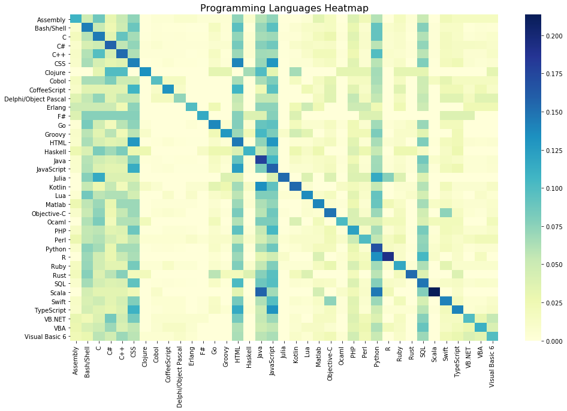

```python
matrix = programming_language_transition.drop('Wanted_PL', axis=1)\
                                        .set_index('Worked_PL')

plt.figure(figsize=(16, 10))
sns.heatmap(matrix, cmap="YlGnBu")
plt.title('Programming Languages Heatmap', size = 16)
plt.ylabel('')
plt.show()
```

- As is evidenced by the diagonal line, people who already work with a programming language have a strong probability of wanting to learn the same programming language.
- People who work with a programming language of a specific area, tend to want to learn programming languages of the same area. For example: HTML is strongly correlated with CSS and JavaScript.

# Which occupations are most popular in Chain

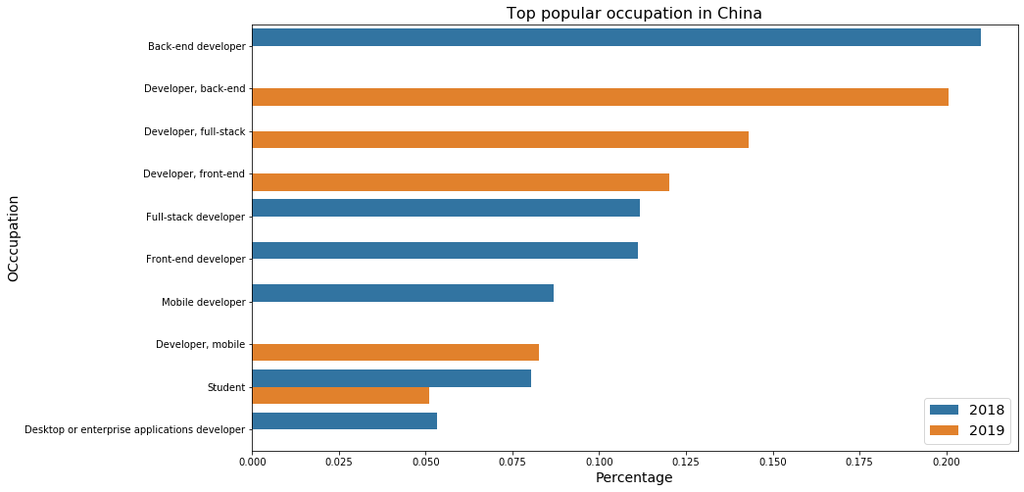

```python
plt.figure(figsize=(14,8))
sns.barplot(x = 'Percentage',
            y = 'Programming Language',
            hue = 'Year',
            data = occupation_chart.sort_values(by='Percentage', ascending=False))

plt.xlabel("Percentage", fontsize = 14)
plt.ylabel("OCccupation", fontsize = 14)
plt.legend(fontsize='x-large', title_fontsize='40')
plt.title('Top popular occupation in China', size = 16)
plt.show()
```

Back-end developer is the most popular occupation among participants in 2018.

# Conclusion

In this article, we took a look at what were the most popular and most biased programming languages, according to Stackoverflow’s 2018 and 2019 Annual Developer Survey data.

- We have seen that some older programming languages such as JavaScript, SQL, and Java still dominates.
- Learning trend is going on as per demand of these languages in China. It seems oldest languages still have their value and are being much demanded.
- People who already work with a certain programming language have a tendency to learn that language or related languages within correlated areas to improve their own skill.
- Back-end developer, Full-stack web developer, Front end developer is the most popular occupation among participants after 2019.

## References

```
- Stackoverflow Developer Survey Data: https://insights.stackoverflow.com/survey
```